# 01_MERS_Data_Audit

```python
# ==========================================================
# MSc Global Health
# Health GIS Project
# MERS-CoV One Health Project
#
# Notebook 01
# Dataset Audit
# ==========================================================
```

```python
import pandas as pd
import numpy as np
import os

pd.set_option("display.max_columns", None)
pd.set_option("display.max_rows", 100)

print("Libraries loaded successfully.")
```

```
Libraries loaded successfully.
```

```python
os.getcwd()
```

```
'C:\\Users\\okpar\\Desktop\\MERS PROJECT'
```

```python
os.listdir()
```

```
['.ipynb_checkpoints',
 '01_MERS_Data_Audit.ipynb',
 'Figures',
 'Outputs',
 'Poster',
 'Presentation',
 'Python',
 'QGIS',
 'Raw_Data',
 'References']
```

```python
os.listdir("Raw_Data")
```

```
['data_04 (1).zip',
 'FAOSTAT_data_en_6-11-2026.csv',
 'WHO-MERS-global-data.csv']
```

```python
who = pd.read_csv("Raw_Data/WHO-MERS-global-data.csv")

print("Dataset loaded successfully.")
print("Rows:", who.shape[0])
print("Columns:", who.shape[1])
```

```
Dataset loaded successfully.
Rows: 27
Columns: 7
```

```python
who.head()
```

|  | Date_downloaded | Country_name | Country_ISO3_code | Who_region | WB_income | Cumulative_cases | Last_date_reported |
| --- | --- | --- | --- | --- | --- | --- | --- |
| 0 | 2025-05-18 | Saudi Arabia | SAU | EMR | HIC | 2217 | 2025-04-20 |
| 1 | 2025-05-18 | Republic of Korea | KOR | WPR | HIC | 186 | 2018-08-26 |
| 2 | 2025-05-18 | United Arab Emirates | ARE | EMR | HIC | 94 | 2023-06-04 |
| 3 | 2025-05-18 | Jordan | JOR | EMR | UMC | 28 | 2015-09-27 |
| 4 | 2025-05-18 | Qatar | QAT | EMR | HIC | 28 | 2022-03-20 |

```python
who.columns
```

```
Index(['Date_downloaded', 'Country_name', 'Country_ISO3_code', 'Who_region',
       'WB_income', 'Cumulative_cases', 'Last_date_reported'],
      dtype='object')
```

```python
who.info()
```

```
<class 'pandas.core.frame.DataFrame'>
RangeIndex: 27 entries, 0 to 26
Data columns (total 7 columns):
 #   Column              Non-Null Count  Dtype
---  ------              --------------  -----
 0   Date_downloaded     27 non-null     object
 1   Country_name        27 non-null     object
 2   Country_ISO3_code   27 non-null     object
 3   Who_region          27 non-null     object
 4   WB_income           27 non-null     object
 5   Cumulative_cases    27 non-null     int64
 6   Last_date_reported  27 non-null     object
dtypes: int64(1), object(6)
memory usage: 1.6+ KB
```

```python
who.isnull().sum()
```

```
Date_downloaded       0
Country_name          0
Country_ISO3_code     0
Who_region            0
WB_income             0
Cumulative_cases      0
Last_date_reported    0
dtype: int64
```

```python
who.sort_values(
    "Cumulative_cases",
    ascending=False
).head(10)
```

|  | Date_downloaded | Country_name | Country_ISO3_code | Who_region | WB_income | Cumulative_cases | Last_date_reported |
| --- | --- | --- | --- | --- | --- | --- | --- |
| 0 | 2025-05-18 | Saudi Arabia | SAU | EMR | HIC | 2217 | 2025-04-20 |
| 1 | 2025-05-18 | Republic of Korea | KOR | WPR | HIC | 186 | 2018-08-26 |
| 2 | 2025-05-18 | United Arab Emirates | ARE | EMR | HIC | 94 | 2023-06-04 |
| 3 | 2025-05-18 | Jordan | JOR | EMR | UMC | 28 | 2015-09-27 |
| 4 | 2025-05-18 | Qatar | QAT | EMR | HIC | 28 | 2022-03-20 |
| 5 | 2025-05-18 | Oman | OMN | EMR | HIC | 26 | 2023-01-01 |
| 6 | 2025-05-18 | Iran (Islamic Republic of) | IRN | EMR | UMC | 6 | 2015-03-22 |
| 7 | 2025-05-18 | United Kingdom of Great Britain and Northern I... | GBR | EUR | HIC | 5 | 2018-08-19 |
| 8 | 2025-05-18 | Kuwait | KWT | EMR | HIC | 4 | 2015-09-13 |
| 9 | 2025-05-18 | Germany | DEU | EUR | HIC | 3 | 2015-02-15 |

```python
who.groupby("Who_region")["Cumulative_cases"]\
   .sum()\
   .sort_values(ascending=False)
```

```
Who_region
EMR     2411
WPR      191
EUR       17
SEAR       3
AFR        2
AMR        2
Name: Cumulative_cases, dtype: int64
```

```python
who.groupby("WB_income")["Cumulative_cases"]\
   .sum()\
   .sort_values(ascending=False)
```

```
WB_income
HIC    2574
UMC      43
LMC       8
LIC       1
Name: Cumulative_cases, dtype: int64
```

```python
who["Cumulative_cases"].sum()
```

```
np.int64(2626)
```

```python
2411 / 2626 * 100
```

```
91.81264280274182
```

```python
fao = pd.read_csv("Raw_Data/FAOSTAT_data_en_6-11-2026.csv")

print("Dataset loaded successfully.")
print("Rows:", fao.shape[0])
print("Columns:", fao.shape[1])
```

```
Dataset loaded successfully.
Rows: 98
Columns: 15
```

```python
fao.head()
```

|  | Domain Code | Domain | Area Code (ISO3) | Area | Element Code | Element | Item Code (CPC) | Item | Year Code | Year | Unit | Value | Flag | Flag Description | Note |
| --- | --- | --- | --- | --- | --- | --- | --- | --- | --- | --- | --- | --- | --- | --- | --- |
| 0 | TCL | Crops and livestock products | DZA | Algeria | 5608 | Import quantity | 2121.01 | Camels | 2024 | 2024 | An | 67 | X | Figure from external organization | Estimated data using trading partners database |
| 1 | TCL | Crops and livestock products | AUS | Australia | 5908 | Export quantity | 2121.01 | Camels | 2024 | 2024 | An | 914 | A | Official figure | NaN |
| 2 | TCL | Crops and livestock products | AUT | Austria | 5608 | Import quantity | 2121.01 | Camels | 2024 | 2024 | An | 6 | A | Official figure | NaN |
| 3 | TCL | Crops and livestock products | AUT | Austria | 5908 | Export quantity | 2121.01 | Camels | 2024 | 2024 | An | 3 | A | Official figure | NaN |
| 4 | TCL | Crops and livestock products | AZE | Azerbaijan | 5608 | Import quantity | 2121.01 | Camels | 2024 | 2024 | An | 41 | A | Official figure | NaN |

```python
fao.columns
```

```
Index(['Domain Code', 'Domain', 'Area Code (ISO3)', 'Area', 'Element Code',
       'Element', 'Item Code (CPC)', 'Item', 'Year Code', 'Year', 'Unit',
       'Value', 'Flag', 'Flag Description', 'Note'],
      dtype='object')
```

```python
fao.info()
```

```
<class 'pandas.core.frame.DataFrame'>
RangeIndex: 98 entries, 0 to 97
Data columns (total 15 columns):
 #   Column            Non-Null Count  Dtype
---  ------            --------------  -----
 0   Domain Code       98 non-null     object
 1   Domain            98 non-null     object
 2   Area Code (ISO3)  98 non-null     object
 3   Area              98 non-null     object
 4   Element Code      98 non-null     int64
 5   Element           98 non-null     object
 6   Item Code (CPC)   98 non-null     float64
 7   Item              98 non-null     object
 8   Year Code         98 non-null     int64
 9   Year              98 non-null     int64
 10  Unit              98 non-null     object
 11  Value             98 non-null     int64
 12  Flag              98 non-null     object
 13  Flag Description  98 non-null     object
 14  Note              28 non-null     object
dtypes: float64(1), int64(4), object(10)
memory usage: 11.6+ KB
```

```python
fao["Element"].value_counts()
```

```
Element
Import quantity    60
Export quantity    38
Name: count, dtype: int64
```

```python
fao["Item"].value_counts()
```

```
Item
Camels            85
Other camelids    13
Name: count, dtype: int64
```

```python
fao["Year"].value_counts()
```

```
Year
2024    98
Name: count, dtype: int64
```

```python
fao["Element"].value_counts()
```

```
Element
Import quantity    60
Export quantity    38
Name: count, dtype: int64
```

```python
fao["Item"].value_counts()
```

```
Item
Camels            85
Other camelids    13
Name: count, dtype: int64
```

```python
# FAOSTAT Trade Dataset Identified
# Dataset contains camel import/export data
# Camel population dataset still required for reservoir analysis
```

```python
camel = pd.read_csv("Raw_Data/FAOSTAT_data_en_6-16-2026.csv")

print("Rows:", camel.shape[0])
print("Columns:", camel.shape[1])
```

```
Rows: 1658
Columns: 15
```

```python
camel.head()
```

|  | Domain Code | Domain | Area Code (M49) | Area | Element Code | Element | Item Code (CPC) | Item | Year Code | Year | Unit | Value | Flag | Flag Description | Note |
| --- | --- | --- | --- | --- | --- | --- | --- | --- | --- | --- | --- | --- | --- | --- | --- |
| 0 | QCL | Crops and livestock products | 4 | Afghanistan | 5111 | Stocks | 2132.0 | Asses | 2024 | 2024 | An | 1530569.0 | I | Value imputed by a receiving agency | NaN |
| 1 | QCL | Crops and livestock products | 4 | Afghanistan | 5111 | Stocks | 2111.0 | Cattle | 2024 | 2024 | An | 5555383.0 | E | Estimated value | NaN |
| 2 | QCL | Crops and livestock products | 4 | Afghanistan | 5112 | Stocks | 2151.0 | Chickens | 2024 | 2024 | 1000 An | 13480.0 | I | Value imputed by a receiving agency | NaN |
| 3 | QCL | Crops and livestock products | 4 | Afghanistan | 5111 | Stocks | 2123.0 | Goats | 2024 | 2024 | An | 8190291.0 | E | Estimated value | NaN |
| 4 | QCL | Crops and livestock products | 4 | Afghanistan | 5111 | Stocks | 2131.0 | Horses | 2024 | 2024 | An | 8262.0 | I | Value imputed by a receiving agency | NaN |

```python
camel.columns
```

```
Index(['Domain Code', 'Domain', 'Area Code (M49)', 'Area', 'Element Code',
       'Element', 'Item Code (CPC)', 'Item', 'Year Code', 'Year', 'Unit',
       'Value', 'Flag', 'Flag Description', 'Note'],
      dtype='object')
```

```python
camel["Item"].value_counts().head(20)
```

```
Item
Cattle               191
Goats                183
Chickens             180
Sheep                178
Swine / pigs         174
Horses               146
Asses                109
Bees                 103
Ducks                 81
Mules and hinnies     69
Turkeys               68
Buffalo               64
Rabbits and hares     55
Geese                 45
Other birds            8
Other camelids         2
Other rodents          2
Name: count, dtype: int64
```

```python
camel["Element"].value_counts()
```

```
Element
Stocks    1658
Name: count, dtype: int64
```

```python
camel["Item"].unique()
```

```
array(['Asses', 'Cattle', 'Chickens', 'Goats', 'Horses',
       'Mules and hinnies', 'Sheep', 'Bees', 'Buffalo', 'Ducks', 'Geese',
       'Swine / pigs', 'Turkeys', 'Rabbits and hares', 'Other camelids',
       'Other rodents', 'Other birds'], dtype=object)
```

```python
camel[camel["Item"].str.contains("camel", case=False, na=False)]
```

|  | Domain Code | Domain | Area Code (M49) | Area | Element Code | Element | Item Code (CPC) | Item | Year Code | Year | Unit | Value | Flag | Flag Description | Note |
| --- | --- | --- | --- | --- | --- | --- | --- | --- | --- | --- | --- | --- | --- | --- | --- |
| 172 | QCL | Crops and livestock products | 68 | Bolivia (Plurinational State of) | 5111 | Stocks | 2121.02 | Other camelids | 2024 | 2024 | An | 3018859.0 | A | Official figure | NaN |
| 1159 | QCL | Crops and livestock products | 604 | Peru | 5111 | Stocks | 2121.02 | Other camelids | 2024 | 2024 | An | 5602727.0 | A | Official figure | NaN |

```python
camel[camel["Item"].str.contains("camel", case=False, na=False)].shape
```

```
(2, 15)
```

```python
camel["Item"].unique()
```

```
array(['Asses', 'Cattle', 'Chickens', 'Goats', 'Horses',
       'Mules and hinnies', 'Sheep', 'Bees', 'Buffalo', 'Ducks', 'Geese',
       'Swine / pigs', 'Turkeys', 'Rabbits and hares', 'Other camelids',
       'Other rodents', 'Other birds'], dtype=object)
```

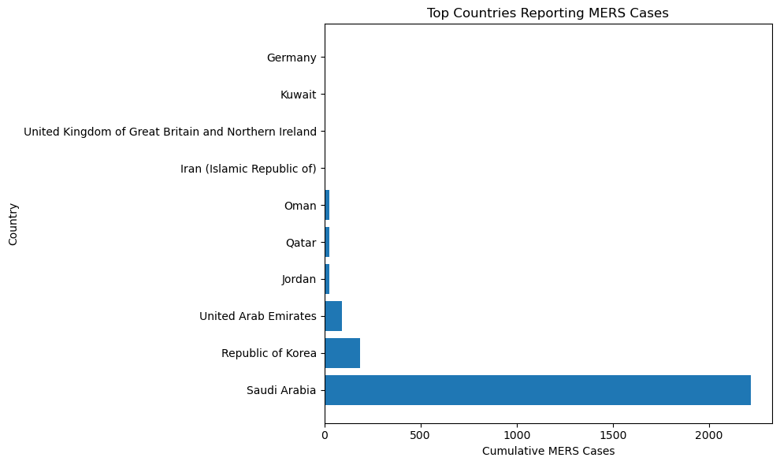

```python
import matplotlib.pyplot as plt

top10 = who.sort_values(
    "Cumulative_cases",
    ascending=False
).head(10)

plt.figure(figsize=(10,6))

plt.barh(
    top10["Country_name"],
    top10["Cumulative_cases"]
)

plt.xlabel("Cumulative MERS Cases")
plt.ylabel("Country")
plt.title("Top Countries Reporting MERS Cases")

plt.tight_layout()

plt.savefig(
    "Figures/Figure_1_Top_MERS_Countries.png",
    dpi=300,
    bbox_inches="tight"
)

plt.show()
```

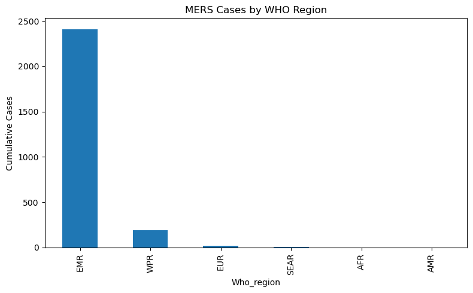

```python
region_cases = (
    who.groupby("Who_region")
       ["Cumulative_cases"]
       .sum()
       .sort_values(ascending=False)
)

plt.figure(figsize=(8,5))

region_cases.plot(kind="bar")

plt.ylabel("Cumulative Cases")
plt.title("MERS Cases by WHO Region")

plt.tight_layout()

plt.savefig(
    "Figures/Figure_2_WHO_Region_Cases.png",
    dpi=300,
    bbox_inches="tight"
)

plt.show()
```

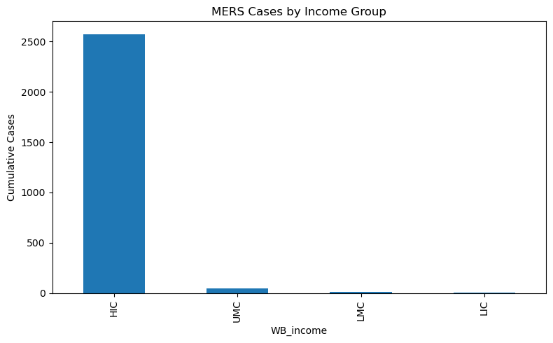

```python
income_cases = (
    who.groupby("WB_income")
       ["Cumulative_cases"]
       .sum()
       .sort_values(ascending=False)
)

plt.figure(figsize=(8,5))

income_cases.plot(kind="bar")

plt.ylabel("Cumulative Cases")
plt.title("MERS Cases by Income Group")

plt.tight_layout()

plt.savefig(
    "Figures/Figure_3_Income_Group_Cases.png",
    dpi=300,
    bbox_inches="tight"
)

plt.show()
```

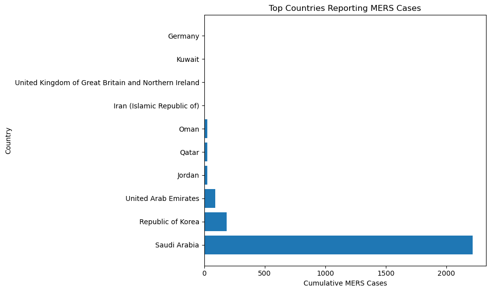

```python
import matplotlib.pyplot as plt

top10 = (
    who.sort_values(
        "Cumulative_cases",
        ascending=False
    )
    .head(10)
)

plt.figure(figsize=(10,6))

plt.barh(
    top10["Country_name"],
    top10["Cumulative_cases"]
)

plt.xlabel("Cumulative MERS Cases")
plt.ylabel("Country")
plt.title("Top Countries Reporting MERS Cases")

plt.tight_layout()

plt.savefig(
    "Figures/Figure_1_Top_MERS_Countries.png",
    dpi=300
)

plt.show()
```

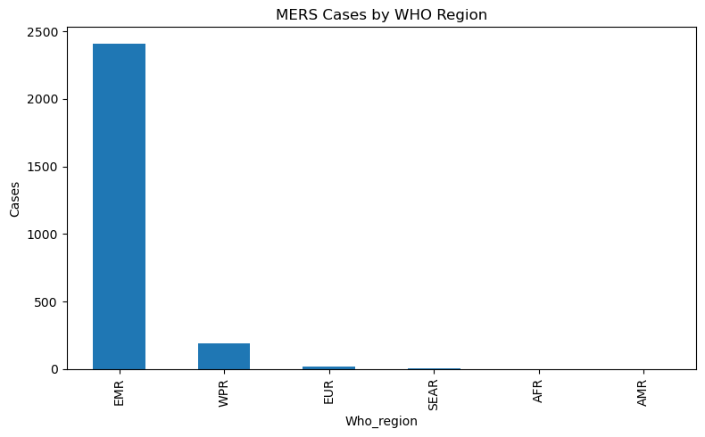

```python
region_cases = (
    who.groupby("Who_region")
       ["Cumulative_cases"]
       .sum()
       .sort_values(ascending=False)
)

plt.figure(figsize=(8,5))

region_cases.plot(kind="bar")

plt.ylabel("Cases")
plt.title("MERS Cases by WHO Region")

plt.tight_layout()

plt.savefig(
    "Figures/Figure_2_WHO_Region_Cases.png",
    dpi=300
)

plt.show()
```

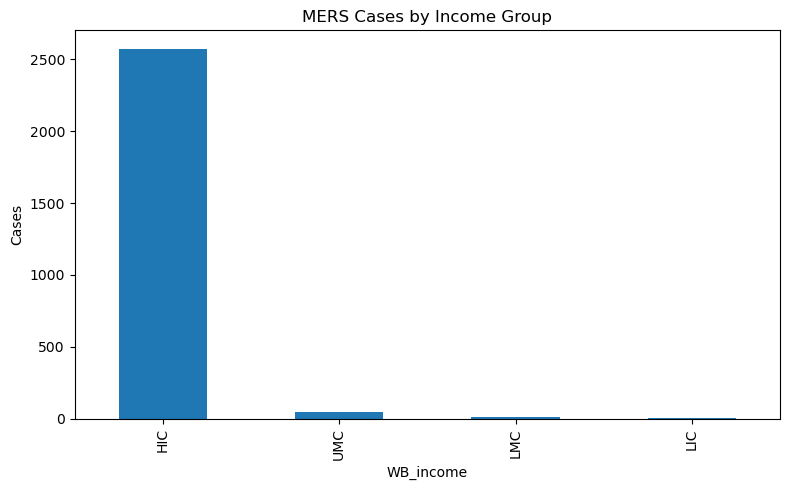

```python
income_cases = (
    who.groupby("WB_income")
       ["Cumulative_cases"]
       .sum()
       .sort_values(ascending=False)
)

plt.figure(figsize=(8,5))

income_cases.plot(kind="bar")

plt.ylabel("Cases")
plt.title("MERS Cases by Income Group")

plt.tight_layout()

plt.savefig(
    "Figures/Figure_3_Income_Group_Cases.png",
    dpi=300
)

plt.show()
```

```python
trade = fao.copy()
```

```python
imports = (
    trade[trade["Element"] == "Import quantity"]
    .sort_values("Value", ascending=False)
)

imports[
    ["Area", "Value"]
].head(15)
```

|  | Area | Value |
| --- | --- | --- |
| 70 | Saudi Arabia | 234480 |
| 28 | Egypt | 87458 |
| 66 | Qatar | 25700 |
| 88 | United Arab Emirates | 10108 |
| 45 | Kuwait | 4930 |
| 60 | Oman | 2000 |
| 58 | Nigeria | 742 |
| 39 | Iraq | 713 |
| 96 | Zambia | 624 |
| 68 | Russian Federation | 551 |
| 51 | Malawi | 520 |
| 74 | Somalia | 400 |
| 91 | United Republic of Tanzania | 292 |
| 19 | China | 238 |
| 20 | China, mainland | 238 |

```python
top_exports = exports.head(10)

plt.figure(figsize=(10,6))

plt.barh(
    top_exports["Area"],
    top_exports["Value"]
)

plt.title("Top Camel Exporting Countries")
plt.xlabel("Number of Camels")

plt.tight_layout()

plt.savefig(
    "Figures/Figure_4_Top_Camel_Exporters.png",
    dpi=300
)

plt.show()
```

[output not shown]

```python
NameError: name 'exports' is not defined
```

[output not shown]

```python
trade = fao.copy()
```

```python
exports = (
    trade[trade["Element"] == "Export quantity"]
    .sort_values("Value", ascending=False)
)
```

```python
exports.head()
```

|  | Domain Code | Domain | Area Code (ISO3) | Area | Element Code | Element | Item Code (CPC) | Item | Year Code | Year | Unit | Value | Flag | Flag Description | Note |
| --- | --- | --- | --- | --- | --- | --- | --- | --- | --- | --- | --- | --- | --- | --- | --- |
| 75 | TCL | Crops and livestock products | SOM | Somalia | 5908 | Export quantity | 2121.01 | Camels | 2024 | 2024 | An | 185678 | X | Figure from external organization | Estimated data using trading partners database |
| 78 | TCL | Crops and livestock products | SDN | Sudan | 5908 | Export quantity | 2121.01 | Camels | 2024 | 2024 | An | 92547 | I | Value imputed by a receiving agency | NaN |
| 27 | TCL | Crops and livestock products | DJI | Djibouti | 5908 | Export quantity | 2121.01 | Camels | 2024 | 2024 | An | 26993 | X | Figure from external organization | Estimated data using trading partners database |
| 71 | TCL | Crops and livestock products | SAU | Saudi Arabia | 5908 | Export quantity | 2121.01 | Camels | 2024 | 2024 | An | 25388 | A | Official figure | NaN |
| 89 | TCL | Crops and livestock products | ARE | United Arab Emirates | 5908 | Export quantity | 2121.01 | Camels | 2024 | 2024 | An | 8851 | X | Figure from external organization | Estimated data using trading partners database |

```python
imports = (
    trade[trade["Element"] == "Import quantity"]
    .sort_values("Value", ascending=False)
)

imports.head()
```

|  | Domain Code | Domain | Area Code (ISO3) | Area | Element Code | Element | Item Code (CPC) | Item | Year Code | Year | Unit | Value | Flag | Flag Description | Note |
| --- | --- | --- | --- | --- | --- | --- | --- | --- | --- | --- | --- | --- | --- | --- | --- |
| 70 | TCL | Crops and livestock products | SAU | Saudi Arabia | 5608 | Import quantity | 2121.01 | Camels | 2024 | 2024 | An | 234480 | A | Official figure | NaN |
| 28 | TCL | Crops and livestock products | EGY | Egypt | 5608 | Import quantity | 2121.01 | Camels | 2024 | 2024 | An | 87458 | I | Value imputed by a receiving agency | NaN |
| 66 | TCL | Crops and livestock products | QAT | Qatar | 5608 | Import quantity | 2121.01 | Camels | 2024 | 2024 | An | 25700 | E | Estimated value | NaN |
| 88 | TCL | Crops and livestock products | ARE | United Arab Emirates | 5608 | Import quantity | 2121.01 | Camels | 2024 | 2024 | An | 10108 | X | Figure from external organization | Estimated data using trading partners database |
| 45 | TCL | Crops and livestock products | KWT | Kuwait | 5608 | Import quantity | 2121.01 | Camels | 2024 | 2024 | An | 4930 | A | Official figure | NaN |

```python
exports = (
    trade[trade["Element"] == "Export quantity"]
    .sort_values("Value", ascending=False)
)

exports.head()
```

|  | Domain Code | Domain | Area Code (ISO3) | Area | Element Code | Element | Item Code (CPC) | Item | Year Code | Year | Unit | Value | Flag | Flag Description | Note |
| --- | --- | --- | --- | --- | --- | --- | --- | --- | --- | --- | --- | --- | --- | --- | --- |
| 75 | TCL | Crops and livestock products | SOM | Somalia | 5908 | Export quantity | 2121.01 | Camels | 2024 | 2024 | An | 185678 | X | Figure from external organization | Estimated data using trading partners database |
| 78 | TCL | Crops and livestock products | SDN | Sudan | 5908 | Export quantity | 2121.01 | Camels | 2024 | 2024 | An | 92547 | I | Value imputed by a receiving agency | NaN |
| 27 | TCL | Crops and livestock products | DJI | Djibouti | 5908 | Export quantity | 2121.01 | Camels | 2024 | 2024 | An | 26993 | X | Figure from external organization | Estimated data using trading partners database |
| 71 | TCL | Crops and livestock products | SAU | Saudi Arabia | 5908 | Export quantity | 2121.01 | Camels | 2024 | 2024 | An | 25388 | A | Official figure | NaN |
| 89 | TCL | Crops and livestock products | ARE | United Arab Emirates | 5908 | Export quantity | 2121.01 | Camels | 2024 | 2024 | An | 8851 | X | Figure from external organization | Estimated data using trading partners database |

```python
exports[
    ["Area", "Value"]
].head(10)
```

|  | Area | Value |
| --- | --- | --- |
| 75 | Somalia | 185678 |
| 78 | Sudan | 92547 |
| 27 | Djibouti | 26993 |
| 71 | Saudi Arabia | 25388 |
| 89 | United Arab Emirates | 8851 |
| 18 | Chile | 4661 |
| 67 | Qatar | 4061 |
| 46 | Kuwait | 3235 |
| 93 | United States of America | 1522 |
| 1 | Australia | 914 |

```python
imports[
    ["Area", "Value"]
].head(10)
```

|  | Area | Value |
| --- | --- | --- |
| 70 | Saudi Arabia | 234480 |
| 28 | Egypt | 87458 |
| 66 | Qatar | 25700 |
| 88 | United Arab Emirates | 10108 |
| 45 | Kuwait | 4930 |
| 60 | Oman | 2000 |
| 58 | Nigeria | 742 |
| 39 | Iraq | 713 |
| 96 | Zambia | 624 |
| 68 | Russian Federation | 551 |

```python
exports.head()
```

|  | Domain Code | Domain | Area Code (ISO3) | Area | Element Code | Element | Item Code (CPC) | Item | Year Code | Year | Unit | Value | Flag | Flag Description | Note |
| --- | --- | --- | --- | --- | --- | --- | --- | --- | --- | --- | --- | --- | --- | --- | --- |
| 75 | TCL | Crops and livestock products | SOM | Somalia | 5908 | Export quantity | 2121.01 | Camels | 2024 | 2024 | An | 185678 | X | Figure from external organization | Estimated data using trading partners database |
| 78 | TCL | Crops and livestock products | SDN | Sudan | 5908 | Export quantity | 2121.01 | Camels | 2024 | 2024 | An | 92547 | I | Value imputed by a receiving agency | NaN |
| 27 | TCL | Crops and livestock products | DJI | Djibouti | 5908 | Export quantity | 2121.01 | Camels | 2024 | 2024 | An | 26993 | X | Figure from external organization | Estimated data using trading partners database |
| 71 | TCL | Crops and livestock products | SAU | Saudi Arabia | 5908 | Export quantity | 2121.01 | Camels | 2024 | 2024 | An | 25388 | A | Official figure | NaN |
| 89 | TCL | Crops and livestock products | ARE | United Arab Emirates | 5908 | Export quantity | 2121.01 | Camels | 2024 | 2024 | An | 8851 | X | Figure from external organization | Estimated data using trading partners database |

```python
imports[["Area","Value"]].head(10).to_csv(
    "Outputs/Top_Camel_Importers.csv",
    index=False
)

exports[["Area","Value"]].head(10).to_csv(
    "Outputs/Top_Camel_Exporters.csv",
    index=False
)

print("Tables saved.")
```

```
Tables saved.
```

Potential One Health Interpretation

Saudi Arabia is the global epicentre of MERS cases and a major hub for camel trade. The country also hosts the annual Hajj pilgrimage, which attracts millions of international visitors and creates a potential pathway for worldwide dissemination of infectious diseases.

# One Health Story Framework

Dromedary camels are the primary animal reservoir of MERS-CoV.

Human infection occurs through direct or indirect contact with infected camels.

Most reported human cases have occurred in Saudi Arabia and neighbouring countries.

Saudi Arabia is also a major hub for camel trade and hosts the annual Hajj pilgrimage.

Millions of pilgrims travel to and from Saudi Arabia every year, creating worldwide human mobility connections.

Although sustained global transmission has not occurred, international travel has resulted in imported MERS cases in several countries.

This demonstrates how animal health, human health, trade and travel are interconnected within a One Health framework.

```python
top10 = who.sort_values(
    "Cumulative_cases",
    ascending=False
)[
    ["Country_name","Cumulative_cases"]
]

top10.head(15)
```

|  | Country_name | Cumulative_cases |
| --- | --- | --- |
| 0 | Saudi Arabia | 2217 |
| 1 | Republic of Korea | 186 |
| 2 | United Arab Emirates | 94 |
| 3 | Jordan | 28 |
| 4 | Qatar | 28 |
| 5 | Oman | 26 |
| 6 | Iran (Islamic Republic of) | 6 |
| 7 | United Kingdom of Great Britain and Northern I... | 5 |
| 8 | Kuwait | 4 |
| 9 | Germany | 3 |
| 10 | Thailand | 3 |
| 11 | Tunisia | 3 |
| 16 | Malaysia | 2 |
| 19 | United States of America | 2 |
| 18 | Philippines | 2 |

## Imported Cases

Several countries reporting MERS cases are not major camel-producing nations.

Examples include:

- Republic of Korea
- Germany
- United Kingdom

This suggests that international travel played a role in the geographic spread of MERS cases.

```python
hajj_story = who[
    who["Country_name"].isin([
        "Saudi Arabia",
        "Republic of Korea",
        "Germany",
        "United Kingdom of Great Britain and Northern Ireland",
        "United Arab Emirates",
        "Qatar",
        "Jordan",
        "Oman"
    ])
]

hajj_story[
    ["Country_name","Cumulative_cases"]
].sort_values(
    "Cumulative_cases",
    ascending=False
)
```

|  | Country_name | Cumulative_cases |
| --- | --- | --- |
| 0 | Saudi Arabia | 2217 |
| 1 | Republic of Korea | 186 |
| 2 | United Arab Emirates | 94 |
| 3 | Jordan | 28 |
| 4 | Qatar | 28 |
| 5 | Oman | 26 |
| 7 | United Kingdom of Great Britain and Northern I... | 5 |
| 9 | Germany | 3 |

```python
hajj_story = (
    who[
        [
            "Country_name",
            "Country_ISO3_code",
            "Cumulative_cases"
        ]
    ]
    .loc[
        who["Country_name"].isin([
            "Saudi Arabia",
            "Republic of Korea",
            "United Arab Emirates",
            "Jordan",
            "Qatar",
            "Oman",
            "Germany",
            "United Kingdom of Great Britain and Northern Ireland"
        ])
    ]
    .sort_values(
        "Cumulative_cases",
        ascending=False
    )
)

hajj_story
```

|  | Country_name | Country_ISO3_code | Cumulative_cases |
| --- | --- | --- | --- |
| 0 | Saudi Arabia | SAU | 2217 |
| 1 | Republic of Korea | KOR | 186 |
| 2 | United Arab Emirates | ARE | 94 |
| 3 | Jordan | JOR | 28 |
| 4 | Qatar | QAT | 28 |
| 5 | Oman | OMN | 26 |
| 7 | United Kingdom of Great Britain and Northern I... | GBR | 5 |
| 9 | Germany | DEU | 3 |

```python
hajj_story.to_csv(
    "Outputs/Hajj_Travel_Risk_Table.csv",
    index=False
)

print("Hajj travel risk table saved.")
```

```
Hajj travel risk table saved.
```

```python
hajj_story
```

|  | Country_name | Country_ISO3_code | Cumulative_cases |
| --- | --- | --- | --- |
| 0 | Saudi Arabia | SAU | 2217 |
| 1 | Republic of Korea | KOR | 186 |
| 2 | United Arab Emirates | ARE | 94 |
| 3 | Jordan | JOR | 28 |
| 4 | Qatar | QAT | 28 |
| 5 | Oman | OMN | 26 |
| 7 | United Kingdom of Great Britain and Northern I... | GBR | 5 |
| 9 | Germany | DEU | 3 |

```python
who_map = who[
    [
        "Country_name",
        "Country_ISO3_code",
        "Cumulative_cases"
    ]
]

who_map.head()
```

|  | Country_name | Country_ISO3_code | Cumulative_cases |
| --- | --- | --- | --- |
| 0 | Saudi Arabia | SAU | 2217 |
| 1 | Republic of Korea | KOR | 186 |
| 2 | United Arab Emirates | ARE | 94 |
| 3 | Jordan | JOR | 28 |
| 4 | Qatar | QAT | 28 |

```python
who_map.to_csv(
    "Outputs/WHO_MERS_Map.csv",
    index=False
)

print("WHO map dataset saved.")
```

```
WHO map dataset saved.
```

```python
import os

os.listdir("Outputs")
```

```
['Hajj_Travel_Risk_Table.csv',
 'Top_Camel_Exporters.csv',
 'Top_Camel_Importers.csv',
 'WHO_MERS_Map.csv']
```